# **famexploreR**

flujo de trabajo para gestión de  
datos de Flora Amenazada de Andalucía

Antonio J. Pérez-Luque

antonio.perez@inia.csic.es

Instituto de Ciencias Forestales (ICIFOR), INIA-CSIC

Juan Lorite

jlorite@ugr.es

Dpto. Botánica, Universidad de Granada

November 25, 2024

# Propuesta

1. Disminuir complejidad manejo datos
   1. Disminuir manipulación datos
   2. Similitud estadillo campo - BBDD
2. Aumentar eficiencia Entrada/Salida Datos
3. Generación Informes de seguimiento de forma sencilla
4. Integración con otras bases de datos
5. Análisis avanzados

## Flujo Trabajo

1. Introducción datos en hojas de cálculo
   1. estandarización nombres archivos
2. Automatizar lectura de datos
3. Generar informes de seguimiento sencillos

# Entrada de datos

### Efecto del vallado sobre Potencial reproductivo, tamaño individual y vecindad

25-30 ind. al azar/población (vallado / no vallado)

- *Potencial reproductivo*: número de flores, frutos y semillas
- *Tamaño individual*: altura, diámetro, biovolumen
- *Vecindad*:
  - distancia a individuos más cercanos (*Nearest Neighbour*)
  - densidad por especie

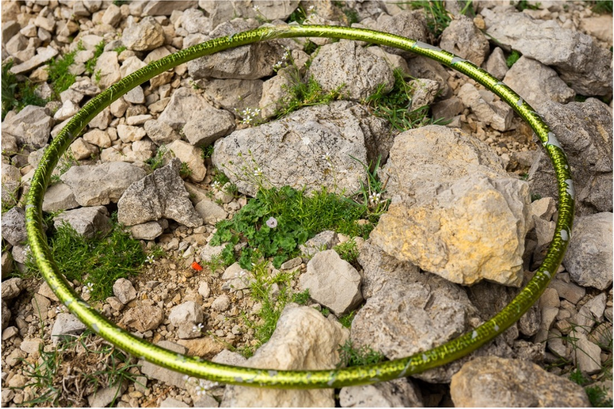

### Efecto del vallado sobre la estructura, composición taxonómica y funcional de la comunidad vegetal

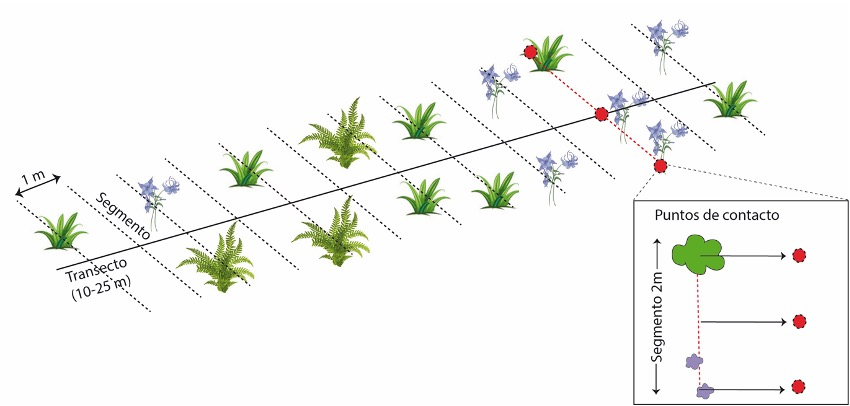

### Estimación del daño por herbivoría

Porcentaje de defoliación en escala semicuantitativa (10 individuos por población, 5 hojas por individuo).

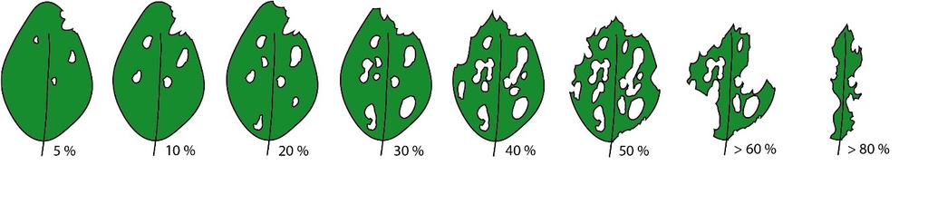

### Densidad ungulados

- Conteo de excrementos: Total excrementos/superficie de 100 m2 en torno a los transecto

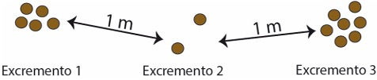

## Estadillo de campo (digital)

- Simple
- Fácil manejo
- Similar a estadillo físico

[Estadillo digital](https://github.com/ajpelu/famexploreR/blob/main/inst/data_ejemplo/ficha_campo.xlsx)

## Estadillo de campo (digital) (II)

- **Estructura**
  - Metadatos
  - Datos
  - Diccionarios

## Estadillo de campo (digital) (III)

- **Metadatos**
  - Introducción datos generales
  - Diccionarios: taxones, tratamintos
  - Importancia de rellenar bien los metadatos

## Estadillo de campo (digital) (IV)

- **Datos**
  - Metadatos heredados
  - Autorrellado de metadatos

## Estadillo de campo (digital) (V)

- **Diccionarios**
  - Modificación por administradores

[figure not shown]

- shiny-app sencilla para ingesta datos
  - modular
  - fácil de usar
  - instalable en cualquier sistema operativo
  - servidor / local
- paquete R
  - portable
  - futuras funcionalidades
- Documentación https://ajpelu.github.io/famexploreR/
- Live-app* http://vlab.iecolab.es/ajpelu/famexploreR/
- Repositorio https://github.com/ajpelu/famexploreR

## [live-app](http://vlab.iecolab.es/ajpelu/famexploreR/)

## Generación Informes

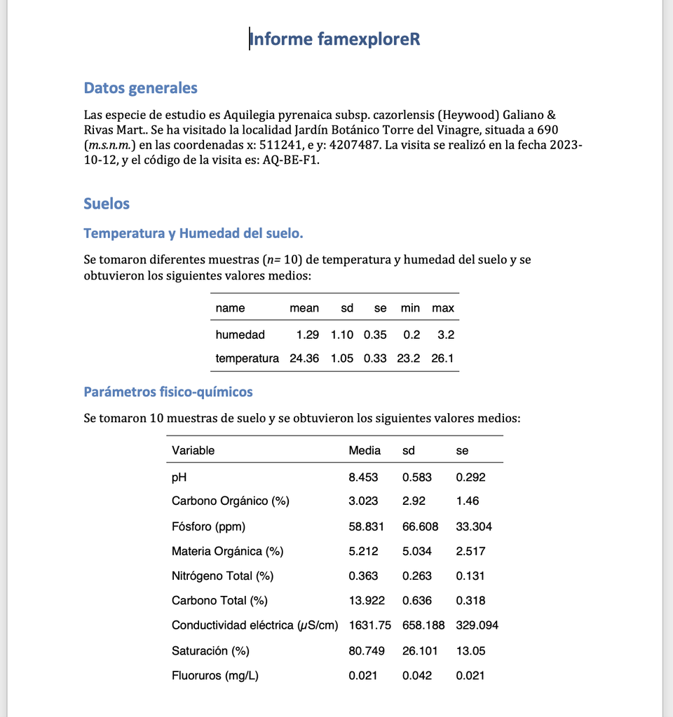

# Siguientes (primeros) pasos

### Evaluar funcionamiento con técnicos de seguimiento

- Tests con más datos reales, más usuarios
- Feedback para mejorar la interfaz y funcionalidades
- Solucionar errores y bugs

### Documentación y mejora del paquete y de la app

### Desarrollo de nuevas funcionalidades

### Implementación de análisis avanzados

### Integración con otras bases de datos (*e.g.* GBIF)

## Muchas gracias por la atención

- [@ajpelu.bsky.social](https://bsky.app/profile/ajpelu.bsky.social)
- antonio.perez@inia.csic.es

Ayuda JDC2022-050056-I financiada por MCIN/AEI /10.13039/501100011033 y por la Unión Europea NextGenerationEU/PRTR

[figure not shown]

Taller Metodologías de Ensayos de Flora